# Module 9: Comparing Visualization Methods in R

Chris Reddish

2025-03-17

## **Introduction**

This report compares **three visualization techniques** in R: **Base R, Lattice, and ggplot2**. We analyze the `USArrests` dataset, which contains crime statistics for the 50 U.S. states. The dataset includes four key variables: - **Murder:** The number of murders per 100,000 residents - **Assault:** The number of assaults per 100,000 residents - **Rape:** The number of rapes per 100,000 residents - **UrbanPop:** The percentage of the population living in urban areas

We will explore how these variables relate and visualize key trends using different R visualization approaches.

```r
# Load necessary libraries
library(lattice)
library(ggplot2)
library(reshape2)
library(ggcorrplot) # For correlation heatmap
# Load dataset
USArrests <- read.csv("USArrests.csv", row.names = 1)
USArrests$State <- rownames(USArrests)
USArrests_long <- melt(USArrests, id.vars = "State", variable.name = "CrimeType", value.name = "Rate")
```

# **1️⃣ Comparison Across Visualization Methods**

## **Histogram of Murder Rates**

Understanding the distribution of **murder rates across states** helps identify which states have **higher crime levels** and if the data follows a normal distribution or is skewed.

### **Base R**

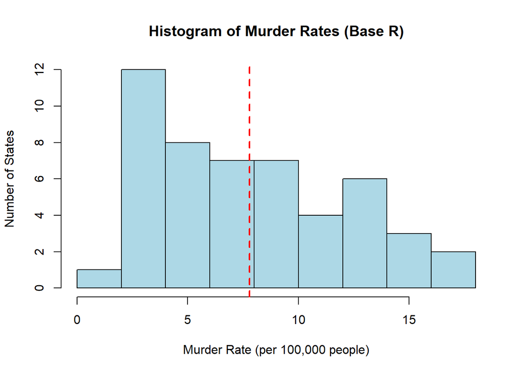

```r
hist(USArrests$Murder,
     breaks = 10, col = "lightblue", border = "black",
     main = "Histogram of Murder Rates (Base R)",
     xlab = "Murder Rate (per 100,000 people)",
     ylab = "Number of States")

abline(v = mean(USArrests$Murder), col = "red", lwd = 2, lty = 2)
```

### **Lattice**

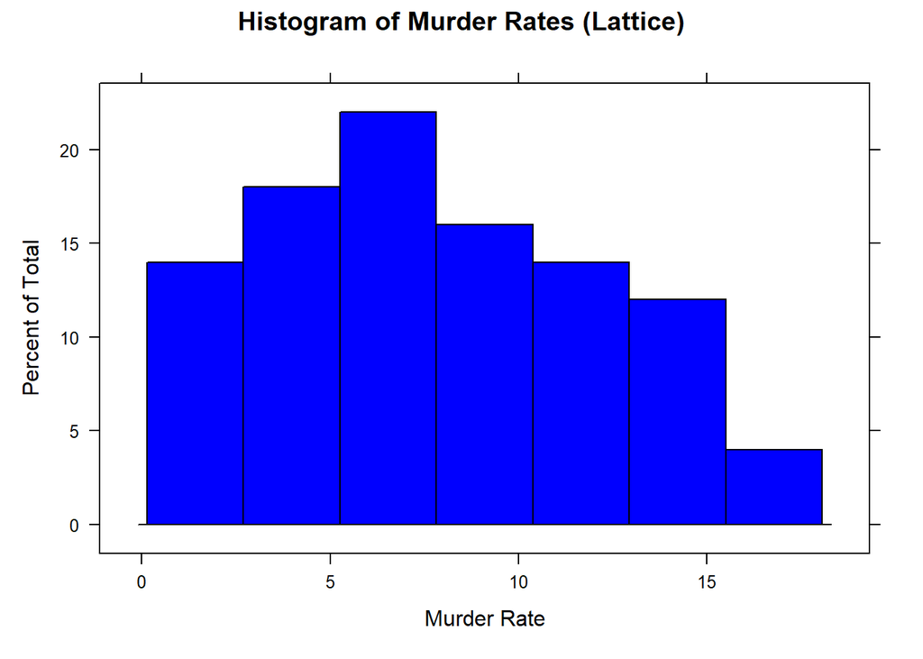

```r
histogram(~Murder, data = USArrests,
          main = "Histogram of Murder Rates (Lattice)",
          xlab = "Murder Rate",
          col = "blue")
```

### **ggplot2**

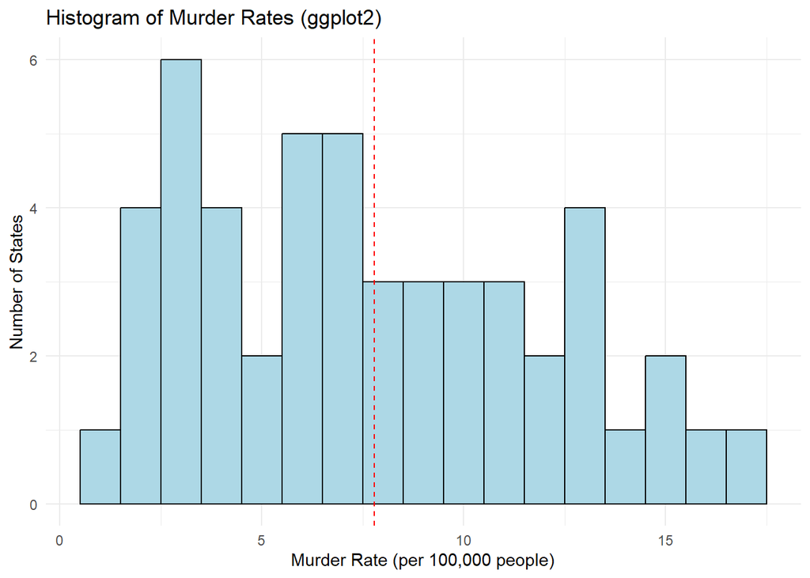

```r
ggplot(USArrests, aes(x = Murder)) +
  geom_histogram(binwidth = 1, fill = "lightblue", color = "black") +
  geom_vline(aes(xintercept = mean(Murder)), color = "red", linetype = "dashed") +
  labs(title = "Histogram of Murder Rates (ggplot2)",
       x = "Murder Rate (per 100,000 people)",
       y = "Number of States") +
  theme_minimal()
```

**What we learn from these histograms:** - The **majority of states** have lower murder rates, with a few having very high rates (right-skewed distribution). - The red line (mean) shows that most states fall **below the national average**. - ggplot2 provides a **more refined visualization**, while base R and lattice are effective but less visually polished.

## **Ordered Bar Chart: Murder Rate by State**

To compare crime levels across states, we rank them from lowest to highest murder rate.

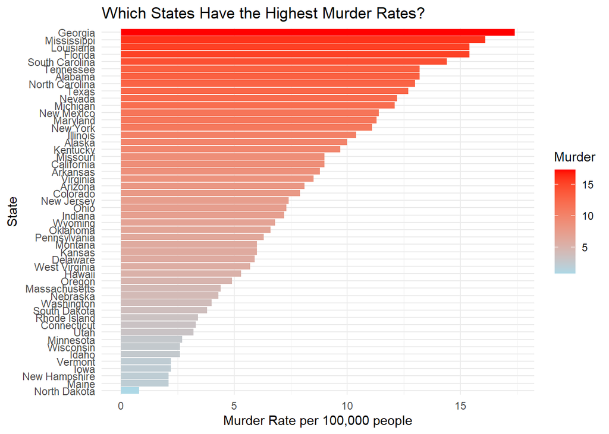

```r
ggplot(USArrests, aes(x = reorder(State, Murder), y = Murder, fill = Murder)) +
  geom_bar(stat = "identity") +
  coord_flip() +
  scale_fill_gradient(low = "lightblue", high = "red") +
  labs(title = "Which States Have the Highest Murder Rates?",
       x = "State",
       y = "Murder Rate per 100,000 people") +
  theme_minimal()
```

**Key insights from this bar chart:** - States with the highest murder rates are clearly highlighted. - The **color gradient** makes it easier to see crime intensity differences. - **Flipping the bars** ensures better readability.

## **Scatter Plot: Murder vs. Assault**

This visualization examines whether **higher assault rates correlate with higher murder rates**.

### **Base R**

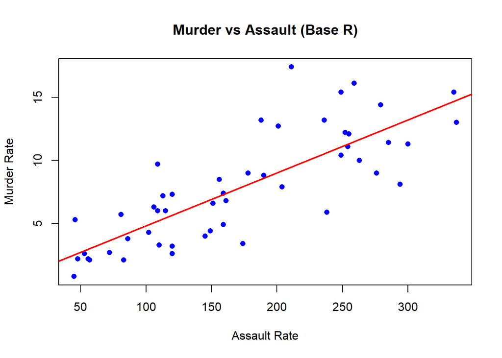

```r
plot(USArrests$Assault, USArrests$Murder,
     main = "Murder vs Assault (Base R)",
     xlab = "Assault Rate",
     ylab = "Murder Rate",
     col = "blue", pch = 16)

abline(lm(Murder ~ Assault, data = USArrests), col = "red", lwd = 2)
```

### **Lattice**

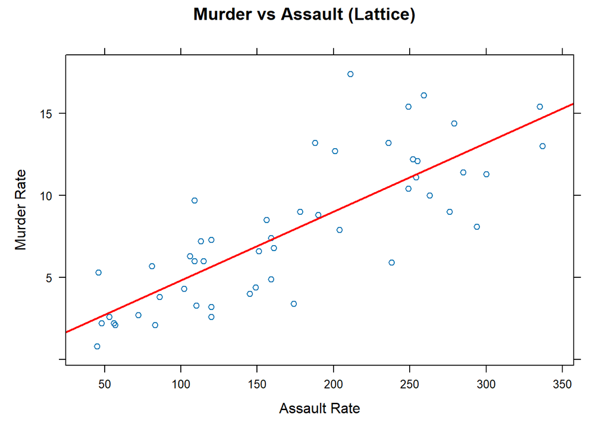

```r
xyplot(Murder ~ Assault, data = USArrests,
       main = "Murder vs Assault (Lattice)",
       xlab = "Assault Rate",
       ylab = "Murder Rate",
       panel = function(x, y, ...) {
           panel.xyplot(x, y, ...)
           panel.abline(lm(y ~ x), col = "red", lwd = 2)
       })
```

### **ggplot2**

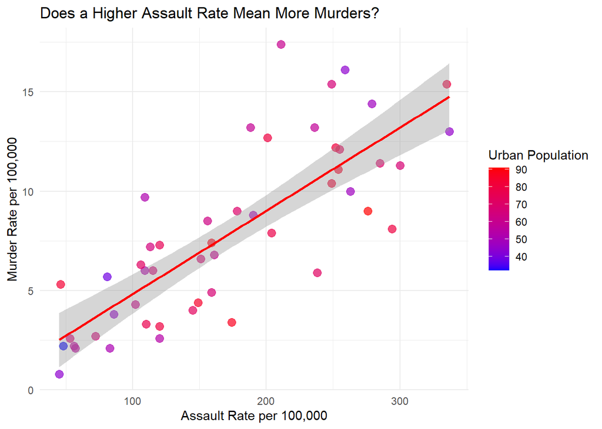

```r
ggplot(USArrests, aes(x = Assault, y = Murder, color = UrbanPop)) +
  geom_point(size = 3, alpha = 0.7) +
  geom_smooth(method = "lm", color = "red") +
  scale_color_gradient(low = "blue", high = "red") +
  labs(title = "Does a Higher Assault Rate Mean More Murders?",
       x = "Assault Rate per 100,000",
       y = "Murder Rate per 100,000",
       color = "Urban Population") +
  theme_minimal()
```

## **Correlation Heatmap of Crime Variables**

```r
# Compute correlation matrix ensuring all values are included
crime_corr <- cor(USArrests[, c("Murder", "Assault", "Rape", "UrbanPop")], use = "everything", method = "pearson")

# Print correlation matrix to check if values are being computed
print(crime_corr)
```

```
##              Murder   Assault      Rape   UrbanPop
## Murder   1.00000000 0.8018733 0.5635788 0.06957262
## Assault  0.80187331 1.0000000 0.6652412 0.25887170
## Rape     0.56357883 0.6652412 1.0000000 0.41134124
## UrbanPop 0.06957262 0.2588717 0.4113412 1.00000000
```

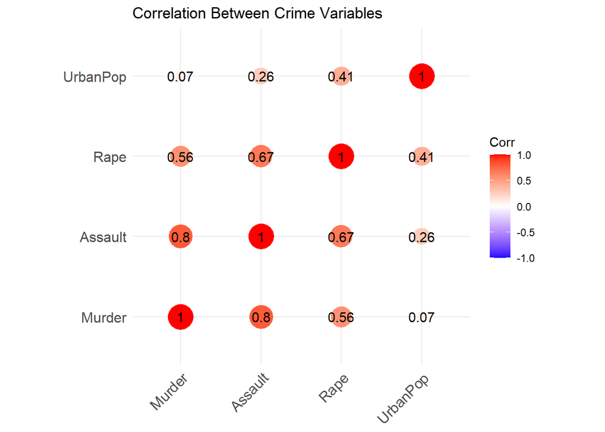

```r
# Create a correlation heatmap with proper spacing
ggcorrplot(crime_corr, method = "circle", type = "full", lab = TRUE,
           title = "Correlation Between Crime Variables",
           outline.col = "white", colors = c("blue", "white", "red"))
```

**Key Takeaways:** - **Murder and Assault are highly correlated**, meaning **states with more assaults also have more murders**. - **Urban population has weaker correlations**, suggesting **crime isn’t just an urban problem**. - The **heatmap provides a great summary of relationships between variables**.

# **Conclusion**

Overall, **ggplot2 offers the clearest insights** into crime trends and relationships, making it the best choice for data-driven decision-making.